# Production Forecasts

Mikko Arvas

11 kesäkuu, 2020

# Read in data

```r
#Get the facility codes
# I had to resort to perl as the gsub below was not complete enough
#$ perl -pe 's/[[:^ascii:]]//g;' facility.txt | perl -pe "s/\"|\'//g" > facility.clean.txt
#
#facility <- as_tibble(read.table("../data/facility.txt",sep = "\t",fill = TRUE,header = TRUE,colClasses = c("character"))[,c(1,2)])
facility <- as_tibble(read.table("../data/facility.clean.txt",sep = "\t",fill = TRUE,header = TRUE,colClasses = c("character"))[,c(1,2)])
facility$AccountNum <- paste0("F",as.character(facility$AccountNum))

#facility$Name <- gsub("[^[:alnum:][:blank:]?&/\\-]", "", facility$Name)

# Get all the files
#PATH <- "/home/esa/production_forecasts/data/FACS/"
PATH <- "~/Work/proj/2019Summer/production_forecasts/data/FACS/"
files <- list.files(path = PATH, pattern = "FAC0091_*")  # Character vector of file names

# Compile a dataframe by going over all files
dlist <- list()
for (i in files) {
  # Read a single file to a df called d
  d <- read.delim(file = paste0(PATH, "/", i), header = FALSE, sep = ";", stringsAsFactors = FALSE, colClasses = 'character')

  if(length(d) == 26){
    d <- d[, !(names(d) %in% c("V10"))]  # The column numbers unfortunately vary between files, so we'll adjust
    }
  colnames(d) <- c("V1", "V2", "V3", "V4", "V5", "V6", "V7", "V8", "V9", "V10",
                   "V11", "V12", "V13", "V14", "V15", "V16", "V17", "V18", "V19", "V20",
                   "V21", "V22", "V23", "V24", "V25")  # This is done so as to have easier column handling later on
  dlist[[i]] <- d
}

d <- as.data.frame(rbindlist(dlist, fill = TRUE))
```

# Format data set

```r
# Divide into distributions (P) and returns (R)
P <- d[d$V1 == "P", ]
R <- d[d$V1 == "R", ]

# For distributions, we'll keep Distribution date, Quantity, Exp date
keep <- c("V12", "V14", "V18", "V22", "V24","V2")
distr <- P[keep]
colnames(distr) <- c("date", "product", "quantity", "volume", "exp","facility")
#Transfrom facility codes into 4 digit numbers
distr$facility <- paste0("F",unlist(lapply(distr$facility,function(x){substr(x,start=nchar(x) -3,stop = nchar(x))})))

#Unfortunately the format of changes in time
R1<- split(x=R,f=nchar(R$V14) == 0)[[1]]
R2<- split(x=R,f=nchar(R$V14) == 0)[[2]]
# For returns we keep the return date and quantity
keep <- c("V4","V5", "V7","V14")
retrn1 <- R1[keep]
keep <- c("V4","V5", "V7","V13")
retrn2 <- R2[keep]

colnames(retrn1) <- c("date", "product","quantity","facility")
colnames(retrn2) <- c("date", "product","quantity","facility")
retrn <- rbind(retrn1,retrn2)
#Transfrom facility codes into 4 digit numbers
retrn$facility <- paste0("F",unlist(lapply(retrn$facility,function(x){substr(x,start=nchar(x) -3,stop = nchar(x))})))

# Datify
distr$date <- dmy(distr$date); distr$exp <- dmy(distr$exp)
retrn$date <- dmy(retrn$date)

# Numerify
distr$quantity <- as.numeric(distr$quantity); distr$volume <- as.numeric(distr$volume)
retrn$quantity <- as.numeric(retrn$quantity)


# Product codes for platelets
#plat.codes <- c("budTR002", "trEnnApu", "A0004V00", "A0005V00", "A0006V00", "A0007V00", "A0008V00",
#"budTR002", "trEnnApu" are not sold products
plat.codes <- c("A0004V00", "A0005V00", "A0006V00", "A0007V00", "A0008V00",
                "A0086VA0", "A0086VB0", "A0086V00", "A0088V00", "A0088VA0", "A0088VB0", "A0089V00",
                "A0089VB0", "A0089VA0", "A0090V00", "A0090VA0", "A0090VB0", "A0018V00", "A0020V00",
                "A0021V00", "A0021VA0", "A0021VB0", "A0047V00", "A0049V00", "A0051V00", "A0054V00",
                "A0055V00", "A0056V00", "A0057V00", "A0059V00", "A0060V00", "A0067VA0", "A0067VB0",
                "A0067V00", "A0068VA0", "A0068VB0", "A0068V00", "A0075V00", "A0101V00", "A0102V00",
                "E3949V00", "E3953V00", "E3954V00", "E3955V00", "E3956V00", "E3957V00", "E3958V00",
                "E3959V00", "E3960V00", "E3961V00", "E3962V00", "E3963V00", "E3964V00", "E3965V00",
                "E3966V00", "E3968VA0", "E3968VB0", "E3968V00", "E3970V00", "E3971V00", "E3973V00",
                "E3974V00", "E3976V00", "E3981V00", "E3995V00", "E3996V00", "E3997V00", "E3997VA0",
                "E3997VB0", "E4002V00", "E4004V00", "E6782V00", "E6783V00", "E6953V00", "E6860V00",
                "E6874VA0", "E6874V00", "E6874VB0", "E6875VB0", "E6875V00", "E7530V00", "E7530VA0",
                "E7530VB0", "E7531V00", "E7531VA0", "E7531VB0", "E6875VA0")

plat.distr <- distr[distr$product %in% plat.codes, ] %>% arrange(date)
plat.retrn <- retrn[retrn$product %in% plat.codes, ] %>% arrange(date)

#Label facilities
plat.distr <- left_join(plat.distr,facility,by = c("facility"="AccountNum"))
retrn.distr <- left_join(plat.retrn,facility,by = c("facility"="AccountNum"))
```

Data starts from 2013-10-28.

# Check the products

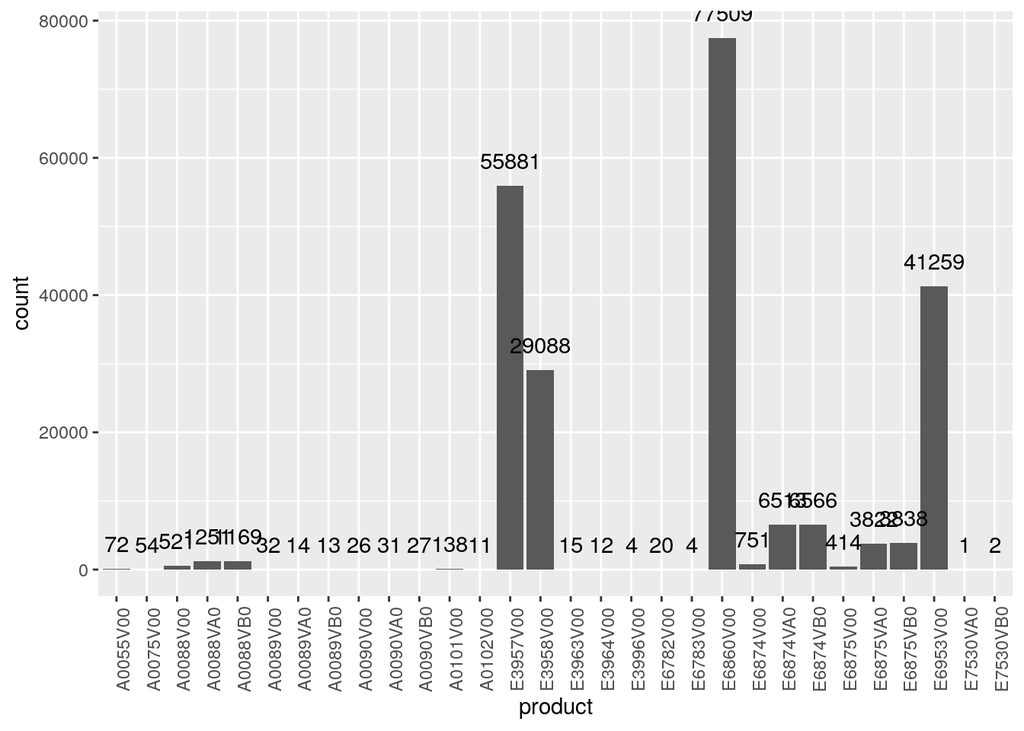

```r
p  <- ggplot(plat.distr,aes(x=product))
p <- p + geom_bar() + theme(axis.text.x = element_text(angle = 90))
p <- p + geom_text(stat='count', aes(label=..count..), vjust=-1)
p
```

Looks like some of them are very rare.

```r
plat.distr %>% group_by(product) %>% summarise(n=n()) %>% filter(n <100)
```

```
## # A tibble: 16 x 2
##    product      n
##    <chr>    <int>
##  1 A0055V00    72
##  2 A0075V00    54
##  3 A0089V00    32
##  4 A0089VA0    14
##  5 A0089VB0    13
##  6 A0090V00    26
##  7 A0090VA0    31
##  8 A0090VB0    27
##  9 A0102V00    11
## 10 E3963V00    15
## 11 E3964V00    12
## 12 E3996V00     4
## 13 E6782V00    20
## 14 E6783V00     4
## 15 E7530VA0     1
## 16 E7530VB0     2
```

How do they change over time?

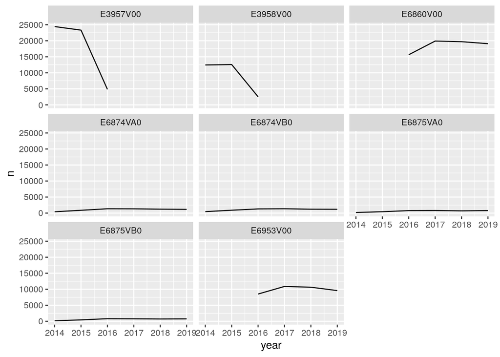

```r
# Get the ones with over 2000 deliveries

over2000 <- plat.distr %>% group_by(product) %>% summarise(n=n()) %>% filter(n > 2000)
yearlycounts<- plat.distr %>% mutate(year=year(date)) %>% group_by(product,year) %>% summarise(n=n()) %>% filter(year > 2013 & year < 2020 )
yearlycounts<- yearlycounts %>% filter(product %in% over2000$product)

p <- ggplot(yearlycounts,aes(x=year,y=n))
p <- p + geom_line() + facet_wrap(~product)
p
```

**Should some products be dropped out?**

**Can all products be counted the same?**

Tiia says no. All can be counted the same.

# Check the volumes

Is there varition in volumes of products with over 2000 deliveries?

```r
summary(plat.distr$volume)
```

```
##     Min.  1st Qu.   Median     Mean  3rd Qu.     Max.
##        0      160      248     1011      256 82629973
```

Wow, nasty!

```r
#Strange volumes above 400
plat.distr %>% filter(volume > 400) %>% select(product,volume,facility)
```

```
##     product   volume facility
## 1  E6860V00    21617    F7109
## 2  E6860V00    21613    F8245
## 3  E6860V00 82629973    F8070
## 4  E6860V00    21714    F8245
## 5  E6860V00 19165312    F8245
## 6  E6860V00      875    F7109
## 7  E6860V00 19165312    F8245
## 8  E6860V00 19165314    F8168
## 9  E6860V00 19165314    F8096
## 10 E6860V00 19165314    F8050
## 11 E6860V00    21720    F8316
## 12 E6860V00   989588    F8229
```

Let’s drop them out

```r
plat.distr <- plat.distr %>% filter(volume <400)
```

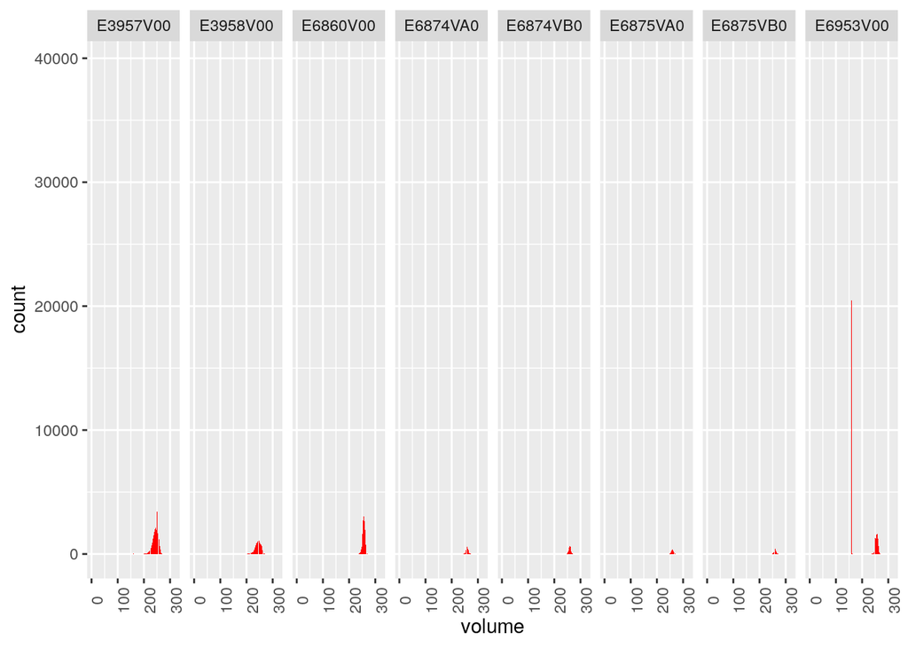

```r
pd <- plat.distr %>% filter(product %in% over2000$product)
p <- ggplot(pd)
p <- p + geom_bar(aes(x=volume),fill='red') + facet_grid(~product) + theme(axis.text.x = element_text(angle = 90))
p
```

E6953V00 has a lot of ~160 volumes.

**Are they still to be counted as one delivery?**

Yes, as Tiia already said. They can be all counted as one :-)!

# Check the facilities and their names

67 facility codes. 65 facility names.

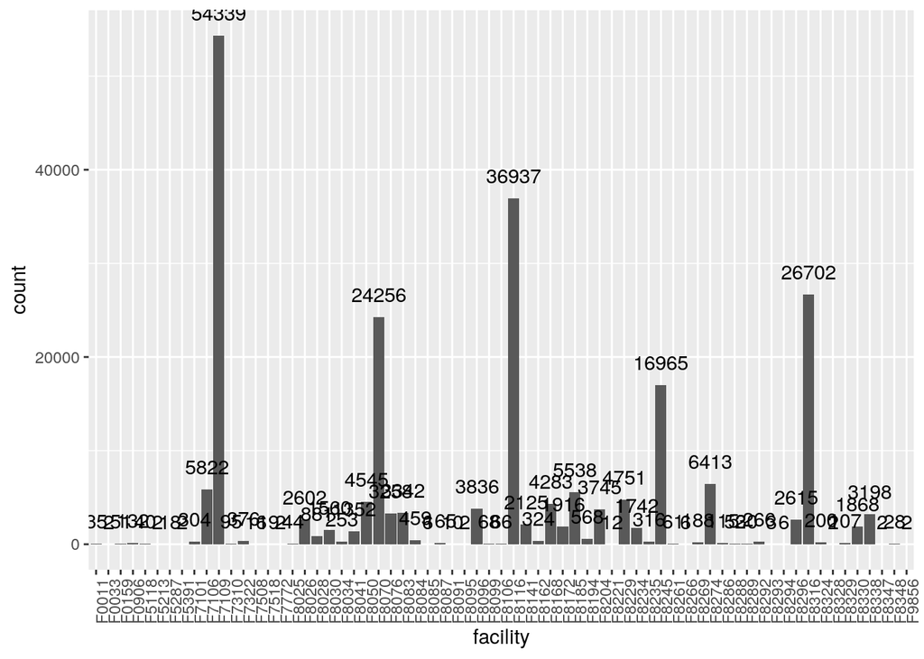

```r
p  <- ggplot(plat.distr,aes(x=facility))
p <- p + geom_bar() + theme(axis.text.x = element_text(angle = 90))
p <- p + geom_text(stat='count', aes(label=..count..), vjust=-1)
p
```

```r
atleast1000 <- plat.distr %>% group_by(Name,facility) %>%  summarise(n=n(),LastYear=year(last(date)))  %>% ungroup() %>%  filter(n > 999) %>% arrange(desc(n))
atleast1000 %>% select(-Name)
```

```
## # A tibble: 24 x 3
##    facility     n LastYear
##    <chr>    <int>    <int>
##  1 F7109    54339     2020
##  2 F8116    36937     2020
##  3 F8316    26702     2020
##  4 F8070    24256     2020
##  5 F8245    16965     2020
##  6 F8274     6413     2020
##  7 F7106     5822     2020
##  8 F8185     5538     2020
##  9 F8229     4751     2020
## 10 F8050     4545     2020
## # … with 14 more rows
```

There are 24 facilities with atleast 1000 platellet products delivered in the data set.

How to they change in time?

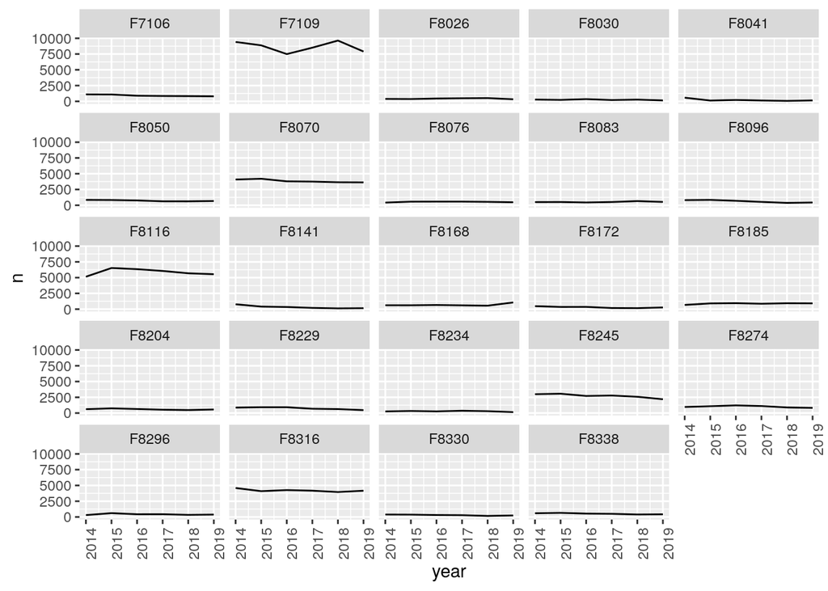

```r
# Get the ones with over 2000 deliveries

if (FALSE) {
  # if you want to so the names a bit
  yearlycounts<- plat.distr %>% mutate(year=year(date)) %>% group_by(facility,year) %>% summarise(n=n(), name=paste0(last(facility)," " ,substr(last(Name),0,10))) %>% filter(year > 2013 & year < 2020 )
} else {
  yearlycounts<- plat.distr %>% mutate(year=year(date)) %>% group_by(facility,year) %>% summarise(n=n(),name=last(facility)) %>% filter(year > 2013 & year < 2020 )
}
yearlycounts<- yearlycounts %>% filter(facility %in% atleast1000$facility) %>% ungroup()

p <- ggplot(yearlycounts,aes(x=year,y=n))
p <- p + geom_line() + facet_wrap(~name) + theme(axis.text.x = element_text(angle = 90))
p
```

```r
leastDeliveries <- plat.distr %>% group_by(Name,facility) %>%  summarise(n=n(),LastYear=year(last(date))) %>% ungroup() %>% top_n(-10) %>% arrange(n)
leastDeliveries$n[leastDeliveries$n < 6] <- "1-5"
leastDeliveries %>% select(-Name)
```

```
## # A tibble: 13 x 3
##    facility n     LastYear
##    <chr>    <chr>    <int>
##  1 F5391    1-5       2014
##  2 F8347    1-5       2016
##  3 F8328    1-5       2017
##  4 F0033    1-5       2014
##  5 F8095    1-5       2015
##  6 F8266    6         2016
##  7 F8294    6         2016
##  8 F8085    6         2015
##  9 F8091    10        2015
## 10 F8221    12        2014
## 11 F0011    35        2017
## 12 F0159    51        2017
## 13 F7322    376       2017
```

```r
leastDeliveries %>% filter(is.na(Name)) %>% select(-Name)
```

```
## # A tibble: 2 x 3
##   facility n     LastYear
##   <chr>    <chr>    <int>
## 1 F8095    1-5       2015
## 2 F8221    12        2014
```

The two lacking facility names are in here. So we do not need to worry about them.

**Do we want to limit to some facilities only?**

Probably we want to limit ourselves to big hospitals only: F8116 TAYS F8070 TYKS F7109 HUS F8316 OYS

```r
length(grep("HUS",unique(plat.distr$Name),value = TRUE))
```

```
## [1] 14
```

Quite a few places under HUS.

**Do we want to group some facilities?** Maybe F7109 will do for HUS.

# Return data

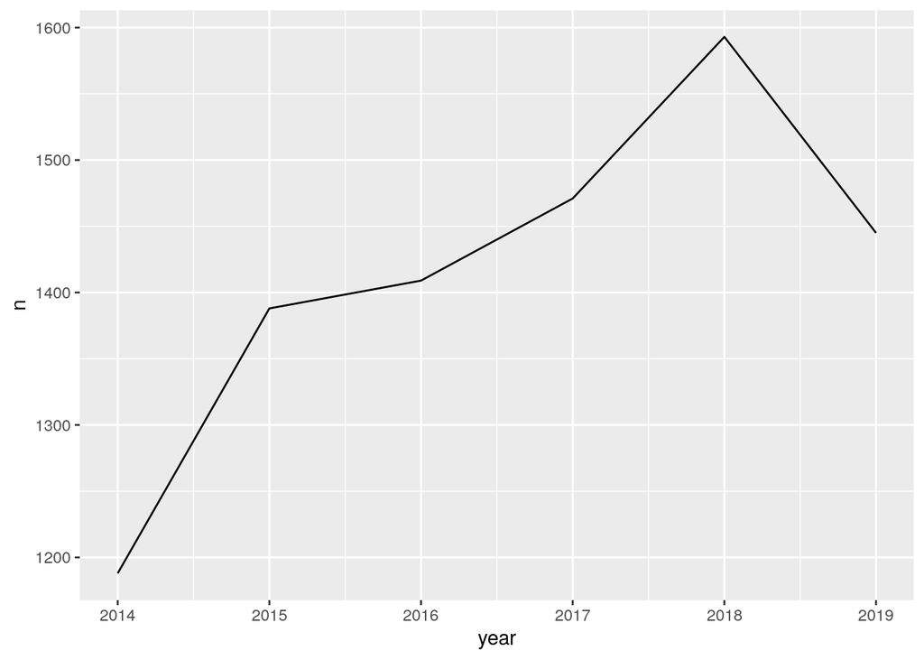

```r
yearlyreturns <- plat.retrn %>% mutate(year=year(date)) %>% group_by(year) %>% summarise( n=n() ) %>% filter(year > 2013 & year < 2020 )

p <- ggplot(yearlyreturns,aes(x=year, y=n))
p <- p + geom_line()
p
```

```r
plat.retrn %>% group_by(facility) %>% count() %>% arrange(desc(n)) %>%  head()
```

```
## # A tibble: 6 x 2
## # Groups:   facility [6]
##   facility     n
##   <chr>    <int>
## 1 F8316     2721
## 2 F8116     2517
## 3 F8070     1706
## 4 F8245     1229
## 5 F7109      186
## 6 F8274       51
```

```r
plat.retrn %>% group_by(facility) %>% count() %>% arrange(desc(n)) %>%  tail()
```

```
## # A tibble: 6 x 2
## # Groups:   facility [6]
##   facility     n
##   <chr>    <int>
## 1 F8028        2
## 2 F8095        2
## 3 F8194        2
## 4 F8329        2
## 5 F0906        1
## 6 F8292        1
```

**Do we want to somehow take returns into account?** Add them in later

# Example data

```r
#Accept all the products
#Only take these facilites
#"F8116","F8070","F7109","F8316"

dailycounts <- plat.distr %>% filter(facility %in% c("F8116","F8070","F7109","F8316")) %>%  group_by(Name,date) %>%  summarise(n=n())
#To anonymise make all counts of 1-5 as "1-5"
dailycounts$n[dailycounts$n < 6] <- "1-5"
dailycounts$Name <- as.factor(dailycounts$Name)
levels(dailycounts$Name) <- c("TAYS","HUS","OYS","TYKS")
dailycounts
```

```
## # A tibble: 7,727 x 3
## # Groups:   Name [4]
##    Name  date       n
##    <fct> <date>     <chr>
##  1 TAYS  2013-10-28 8
##  2 TAYS  2013-10-29 28
##  3 TAYS  2013-10-30 12
##  4 TAYS  2013-10-31 14
##  5 TAYS  2013-11-25 24
##  6 TAYS  2013-11-26 22
##  7 TAYS  2013-11-27 44
##  8 TAYS  2013-11-28 18
##  9 TAYS  2013-11-29 46
## 10 TAYS  2013-11-30 8
## # … with 7,717 more rows
```

But how many are then actually 1-5?

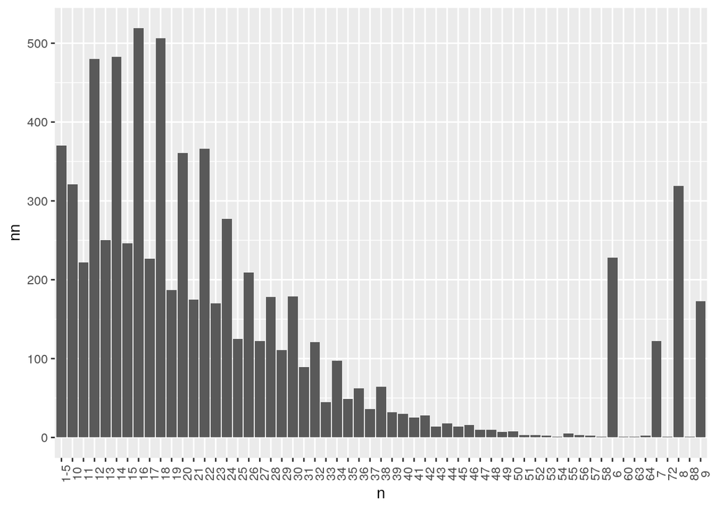

```r
freqs <- dailycounts %>% ungroup %>% select(-Name) %>% count(n) %>% arrange(nn)

p <- ggplot(freqs,aes(y=nn,x=n))
p <- p + geom_col() + theme(axis.text.x = element_text(angle = 90))
#p <- p + geom_text(stat='count', aes(label=..count..), vjust=-1)
p
```

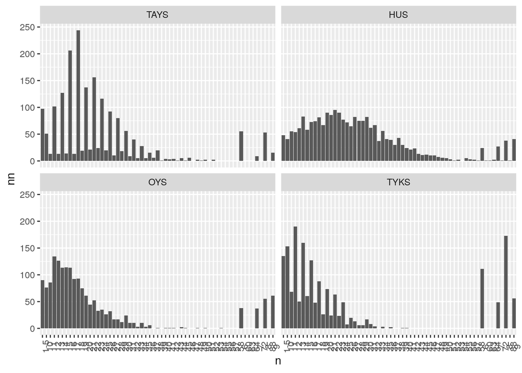

```r
freqs <- dailycounts %>% group_by(Name) %>% count(n) %>% arrange(nn)

p <- ggplot(freqs,aes(y=nn,x=n))
p <- p + geom_col() + theme(axis.text.x = element_text(angle = 90)) + facet_wrap(~Name)
#p <- p + geom_text(stat='count', aes(label=..count..), vjust=-1)
p
```

Looks a bit funny, but it could do. ** Ellie says it is OK**

# All hospitals

Tiia thought it would be best to include all hospitals in the delivery.

```r
library("xlsx")
hospitals <- read.xlsx("../data/SairaalaAsiakkaat2012_Tiilta.xlsx",sheetIndex = 1)
hcode  <- paste0("F",gsub(" .*","",gsub("^ ","",hospitals[,1])))
hname  <- substr(x=sub("^ ","",hospitals[,1]),start = 7,stop = 50)
hospitals <- data.frame(facility = hcode,name=hname)
```

```r
#Accept all the products
#Only take jhospitals
#"F8116","F8070","F7109","F8316"

dailycounts <- plat.distr %>% filter(facility %in% hospitals$facility)   %>%  group_by(facility,date) %>%  summarise(n=n())
#Names come put much better from the Hospitals object
dailycounts <- inner_join(dailycounts,hospitals, by = c("facility"="facility")) %>% ungroup() %>% select(-facility)
```

## Provide descriptives of counts

First bin the hospitals a bit based on delivires in year 2019

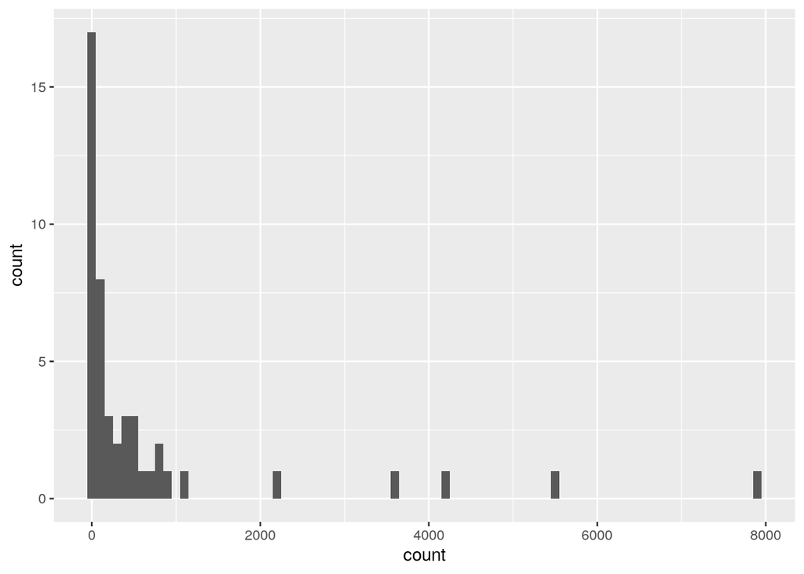

```r
count2019<- dailycounts %>% filter(date >= "2019-01-01"  & date <= "2019-12-31") %>%  group_by(name) %>% summarise(count=sum(n))
ggplot(count2019) + geom_histogram(aes(x=count),binwidth = 100)
```

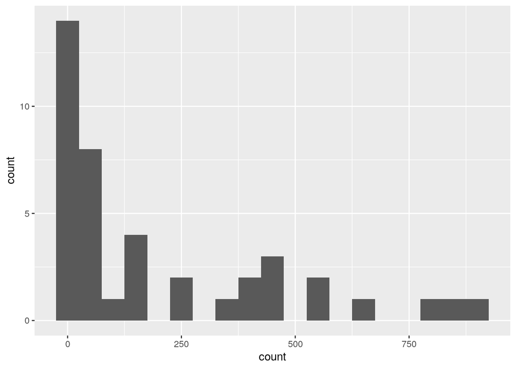

```r
ggplot(count2019 %>% filter(count < 1000)) + geom_histogram(aes(x=count),binwidth = 50)
```

Based on that lets bin them by 100 and 1000.

```r
count2019 <- count2019 %>% mutate( size = case_when(count < 100 ~ "small",
                                       count >= 100 & count < 1000 ~ "medium",
                                       count >= 1000 ~ "large" )
                      )

dailycounts<- left_join(dailycounts,count2019,by=c("name"="name")) %>% select(-count)
#Mark NAs as small
dailycounts$size[is.na(dailycounts$size)] <- "small"
```

Summarise by group and year

```r
#https://www.r-bloggers.com/computing-the-mode-in-r/
Mode = function(x){
    ta = table(x)
    tam = max(ta)
    if (all(ta == tam))
         mod = NA
    else
         if(is.numeric(x))
    mod = as.numeric(names(ta)[ta == tam])
    else
         mod = names(ta)[ta == tam]
    return(mod)
}


descs <- dailycounts %>% mutate(year=year(date)) %>% group_by(size,year) %>% summarise(mean=mean(n),
                                                                              sd=sd(n),
                                                                              median=median(n),
                                                                              q25=quantile(n,0.25),
                                                                              q75=quantile(n,0.75),
                                                                              mode1=Mode(n)[1],
                                                                              mode2=Mode(n)[2]
                                                                              )

write.csv(descs,file="../results/20200611delivery_descs.csv",row.names = FALSE)
```

```r
#To anonymise make all counts of 1-5 as "1-5"
dailycounts$n[dailycounts$n < 6] <- "1-5"
dailycounts$class <- "delivery"
dailycounts
```

```
## # A tibble: 31,919 x 5
##    date       n     name                             size  class
##    <date>     <chr> <fct>                            <chr> <chr>
##  1 2018-02-25 1-5   STELLA OY KOTISAIRAALA, HELSINKI small delivery
##  2 2018-02-27 1-5   STELLA OY KOTISAIRAALA, HELSINKI small delivery
##  3 2018-03-01 1-5   STELLA OY KOTISAIRAALA, HELSINKI small delivery
##  4 2018-03-05 1-5   STELLA OY KOTISAIRAALA, HELSINKI small delivery
##  5 2018-03-07 1-5   STELLA OY KOTISAIRAALA, HELSINKI small delivery
##  6 2018-03-13 1-5   STELLA OY KOTISAIRAALA, HELSINKI small delivery
##  7 2018-03-17 1-5   STELLA OY KOTISAIRAALA, HELSINKI small delivery
##  8 2018-03-21 1-5   STELLA OY KOTISAIRAALA, HELSINKI small delivery
##  9 2018-03-26 1-5   STELLA OY KOTISAIRAALA, HELSINKI small delivery
## 10 2018-03-29 1-5   STELLA OY KOTISAIRAALA, HELSINKI small delivery
## # … with 31,909 more rows
```

## Add the returns

```r
#add the names
returns <- inner_join(plat.retrn,hospitals, by = c("facility"="facility")) %>% select(-facility)
dailyreturns <- returns %>%  group_by(name,date) %>%  summarise(n=n())
dailyreturns$class <- "return"
dailyreturns <- dailyreturns %>% select(date,n,name,class)
#Add the size class
dailyreturns<- left_join(dailyreturns,count2019,by=c("name"="name")) %>% select(-count)
#Mark NAs as small
dailyreturns$size[is.na(dailyreturns$size)] <- "small"

#dailyreturns
```

```r
descs <- dailyreturns %>% mutate(year=year(date)) %>% group_by(size,year) %>% summarise(mean=mean(n),
                                                                              sd=sd(n),
                                                                              median=median(n),
                                                                              q25=quantile(n,0.25),
                                                                              q75=quantile(n,0.75),
                                                                              mode1=Mode(n)[1],
                                                                              mode2=Mode(n)[2]
                                                                              )

write.csv(descs,file="../results/20200611returns_descs.csv",row.names = FALSE)
descs
```

```
## # A tibble: 23 x 9
## # Groups:   size [3]
##    size    year  mean    sd median   q25   q75 mode1 mode2
##    <chr>  <int> <dbl> <dbl>  <dbl> <dbl> <dbl> <dbl> <dbl>
##  1 large   2013  4.81  4.17      4  2        6     2     4
##  2 large   2014  3.68  2.91      3  2        5     1    NA
##  3 large   2015  3.98  3.19      3  2        6     1    NA
##  4 large   2016  4.26  3.74      3  2        6     1     2
##  5 large   2017  4.34  3.95      3  1        6     1    NA
##  6 large   2018  4.51  4.23      3  2        6     1    NA
##  7 large   2019  3.85  3.53      3  1        5     1    NA
##  8 large   2020  3.87  2.85      3  2        5     3    NA
##  9 medium  2013  2     0         2  2        2    NA    NA
## 10 medium  2014  2.05  1.20      2  1.75     2     2    NA
## # … with 13 more rows
```

Anomymise and join

```r
#To anonymise make all counts of 1-5 as "1-5"
dailyreturns$n[dailyreturns$n < 6] <- "1-5"

daily <- bind_rows(dailycounts,dailyreturns) %>% ungroup()%>% arrange(date)

head(daily)
```

```
## # A tibble: 6 x 5
##   date       n     name                                 size   class
##   <date>     <chr> <fct>                                <chr>  <chr>
## 1 2013-10-28 14    HUSLAB MEILAHTI VERIKESKUS           large  delivery
## 2 2013-10-28 1-5   HUSLAB HYVINKÄÄN SAIRAALA VERIKESKUS medium delivery
## 3 2013-10-28 6     PHKS VERIKESKUS, LAHTI               medium delivery
## 4 2013-10-28 12    TYKSLAB VERIKESKUS                   large  delivery
## 5 2013-10-28 1-5   HUSLAB JORVIN SAIRAALA VERIKESKUS    medium delivery
## 6 2013-10-28 1-5   HUSLAB PEIJAKSEN SAIRAALA VERIKESKUS medium delivery
```

```r
tail(daily)
```

```
## # A tibble: 6 x 5
##   date       n     name                           size   class
##   <date>     <chr> <fct>                          <chr>  <chr>
## 1 2020-02-28 23    NORDLAB OULU VERIKESKUS        large  delivery
## 2 2020-02-28 1-5   TYKSLAB VERIKESKUS             large  return
## 3 2020-02-29 1-5   HUSLAB TÖÖLÖN SAIRAALA         medium delivery
## 4 2020-02-29 26    HUSLAB MEILAHTI VERIKESKUS     large  delivery
## 5 2020-02-29 1-5   FIMLAB  HÄMEENLINNA VERIKESKUS medium delivery
## 6 2020-02-29 6     FIMLAB TAMPERE VERIKESKUS      large  delivery
```

## Summarise a bit

```r
daily %>% mutate(Year=year(date)) %>% group_by(Year,class) %>% count() %>% tail(10)
```

```
## # A tibble: 10 x 3
## # Groups:   Year, class [10]
##     Year class        n
##    <int> <chr>    <int>
##  1  2016 delivery  5124
##  2  2016 return     352
##  3  2017 delivery  4960
##  4  2017 return     359
##  5  2018 delivery  4800
##  6  2018 return     373
##  7  2019 delivery  4748
##  8  2019 return     389
##  9  2020 delivery   769
## 10  2020 return      60
```

This is not counts of bags but counts of days with a delivery or return to/from hospital.

```r
daily %>% group_by(name,class) %>% count() %>% arrange(desc(n)) %>% head(10)
```

```
## # A tibble: 10 x 3
## # Groups:   name, class [10]
##    name                          class        n
##    <fct>                         <chr>    <int>
##  1 HUSLAB MEILAHTI VERIKESKUS    delivery  2284
##  2 FIMLAB TAMPERE VERIKESKUS     delivery  1921
##  3 TYKSLAB VERIKESKUS            delivery  1814
##  4 ISLAB KUOPIO VERIKESKUS       delivery  1748
##  5 HUSLAB TÖÖLÖN SAIRAALA        delivery  1716
##  6 NORDLAB OULU VERIKESKUS       delivery  1708
##  7 ISLAB JOENSUU  VERIKESKUS     delivery  1688
##  8 EKKS VERIKESKUS, LAPPEENRANTA delivery  1437
##  9 PHKS VERIKESKUS, LAHTI        delivery  1356
## 10 KYMKS VERIKESKUS, KOTKA       delivery  1319
```

```r
daily %>% group_by(name,class) %>% count() %>% arrange(desc(n)) %>% tail(10)
```

```
## # A tibble: 10 x 3
## # Groups:   name, class [10]
##    name                                class        n
##    <fct>                               <chr>    <int>
##  1 HUSLAB PORVOON SAIRAALA             return       1
##  2 HYVINKÄÄN TERVEYSKESKUS LABORATORIO return       1
##  3 ISLAB SAVONLINNA VERIKESKUS         return       1
##  4 ISLAB VARKAUDEN SAIRAALA VERIKESKUS return       1
##  5 KUUSAMON TK VERIKESKUS              return       1
##  6 NORDLAB OULASKANGAS VERIKESKUS      return       1
##  7 POSION TERVEYSKESKUS                delivery     1
##  8 REGION GÄVLEBORG LABORATORIE-       delivery     1
##  9 TAIVALKOSKEN TERVEYSKESKUS          delivery     1
## 10 TERVEYSTALO KAMPPI, HELSINKI        delivery     1
```

This is not counts of bags but counts of days with a delivery or return to/from hospital.

Looks OK.

```r
file <- "../results/20200611DailyCountsOfPlateletReturnsAndDeliveries.txt"
write.table(daily,file=file,sep = ";",row.names = FALSE,quote = FALSE)
```